# Data Analysis on Crop Yield

Rice appears to benefit more from rainy conditions, which is consistent with the fact that rice is typically grown in areas with ample water. The higher yield under rainy weather indicates that water availability is a key factor for optimal rice production.

Like rice, soy beans also seem to benefit from more water (rain), leading to higher yields during rainy weather. This indicates that adequate moisture is essential for maximizing soy bean growth.

Similar to rice and soy beans, wheat seems to thrive with more moisture from rain.

**Do rainy conditions result in a higher or lower yield compared to sunny or cloudy weather?**

Based on the previous analysis, rainy conditions result in a higher yield for certain crops when compared to sunny or cloudy weather.

Rainy weather generally results in higher yields for crops like rice, soy bean and wheat, as they thrive with more moisture.

For barley, cloudy weather appears to be optimal, while cotton and maize show stable performance across all weather conditions.

**Does the use of irrigation increase the crop yield compared to crops that were not irrigated?**

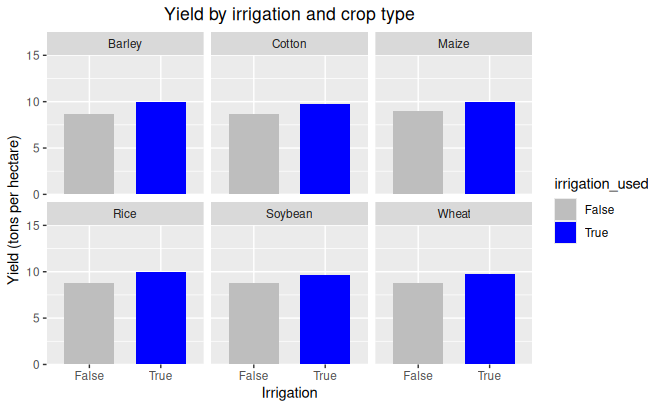

```r
data %>%
  ggplot(aes(x = irrigation_used, y = yield_tons_per_hectare, fill = irrigation_used)) +
  geom_bar(stat = "identity", position = "dodge", width = 0.7) +
  facet_wrap(~crop) +
  scale_y_continuous(limits = c(0, 15), expand = c(0, 0)) +
  scale_fill_manual(values = c("False" = "grey", "True" = "blue")) +
  labs(title = "Yield by irrigation and crop type",
       x = "Irrigation",
       y = "Yield (tons per hectare)") +   theme(plot.title = element_text(hjust = 0.5))
```

The bar chart illustrates the impact of irrigation on crop yield across different crop types. The “False” category represents crops where no irrigation was used, while the “True” category indicates that irrigation was applied, highlighted in blue.

In all crop types shown, the use of irrigation (True) is associated with a noticeable increase in crop yield, as compared to the “False” category, where no irrigation was utilized.

**In which regions does irrigation have the most significant effect on yield?**

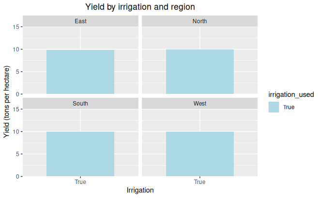

```r
data %>%
  filter(irrigation_used == "True") %>%  # Filter to show only True values
  ggplot(aes(x = irrigation_used, y = yield_tons_per_hectare, fill = irrigation_used)) +
  geom_bar(stat = "identity", position = "dodge", width = 0.7) +
  facet_wrap(~region) +
  scale_y_continuous(limits = c(0, 15), expand = c(0, 0)) +
  scale_fill_manual(values = c("True" = "lightblue")) +
  labs(title = "Yield by irrigation and region",
       x = "Irrigation",
       y = "Yield (tons per hectare)") +
  theme (plot.title = element_text(hjust = 0.5))
```

**How does the impact of irrigation vary across different crop types and soil types?**

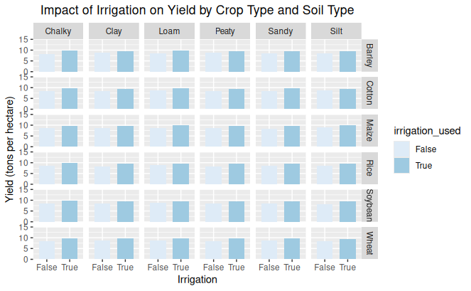

```r
data %>%
  ggplot(aes(x = irrigation_used, y = yield_tons_per_hectare, fill = irrigation_used)) +
  geom_bar(stat = "identity", position = "dodge", width = 0.7) +
  facet_grid(crop ~ soil_type) +
  scale_y_continuous(limits = c(0, 15), expand = c(0, 0)) +
  scale_fill_brewer(palette = "Blues") +
  labs(title = "Impact of Irrigation on Yield by Crop Type and Soil Type",
       x = "Irrigation",
       y = "Yield (tons per hectare)") + theme(plot.title = element_text(hjust = 0.5))
```

**Does the use of fertilizer application increase the crop yield compared to crops that were not fertilized?**

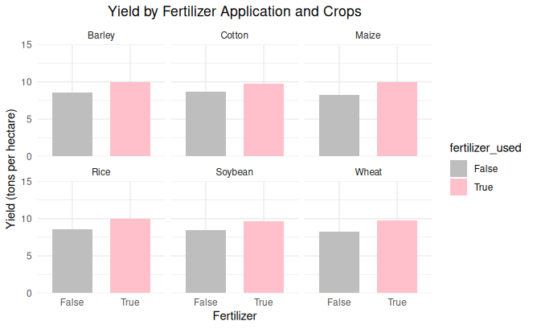

```r
data %>% ggplot(aes(x = fertilizer_used, y = yield_tons_per_hectare, fill = fertilizer_used)) +
  geom_bar(stat = "identity", position = "dodge", width = 0.7) +
  facet_wrap(~crop) +
  scale_y_continuous(limits = c(0,15), expand = c(0,0)) +
  scale_fill_manual(values = c("False" = "grey", "True" = "pink")) +
  labs(title = "Yield by Fertilizer Application and Crops",
       x = "Fertilizer",
       y = "Yield (tons per hectare)"
       ) +
  theme_minimal() + theme(plot.title = element_text(hjust = 0.5))
```

The bar chart illustrates the impact of fertilizer on crop yield across different crop types. The “False” category represents crops where no fertilizer was applied, while the “True” category indicates that fertilizer was applied, highlighted in pink.

In all crop types shown, the application of fertilizer (True) is associated with a noticeable increase in crop yield, as compared to the “False” category, where no fertilizer was applied.

**How do crop yields differ by region (North, East, South, West)?**

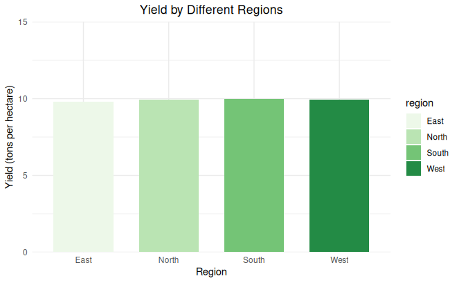

```r
data %>% ggplot(aes(x = region, y = yield_tons_per_hectare, fill = region)) +
  geom_bar(stat= "identity", position = "dodge", width = 0.7) +
  scale_y_continuous(limits = c(0,15), expand = c(0,0)) +
  scale_fill_brewer(palette = "Greens") +
  labs(title = "Yield by Different Regions",
       x = "Region",
       y = "Yield (tons per hectare)"
       ) + theme_minimal() +
  theme(plot.title = element_text(hjust = 0.5))
```

The chart above illustrates how crop yields differ by region (East, North, South, West). Each region is represented by distinct shades of green. Upon examining the plot, it becomes evident that the North, South and West regions exhibit nearly identical crop yields in tons per hectare.

The East region, while still performing reasonably well, shows a slightly lower yield when compared to the other regions, though this difference is not statistically significant.

**What is the relationship between temperature and rainfall with respect to crop yield in different regions?**

```r
# Calculate the correlation matrix
corr_matrix <- data %>%
  select(temperature_celsius, rainfall_mm, yield_tons_per_hectare) %>%
  cor(use = "complete.obs")

# Print the correlation matrix
print(corr_matrix)
```

```
                       temperature_celsius   rainfall_mm yield_tons_per_hectare
temperature_celsius           1.0000000000 -0.0003705305             0.08521338
rainfall_mm                  -0.0003705305  1.0000000000             0.76451165
yield_tons_per_hectare        0.0852133840  0.7645116453             1.00000000
```

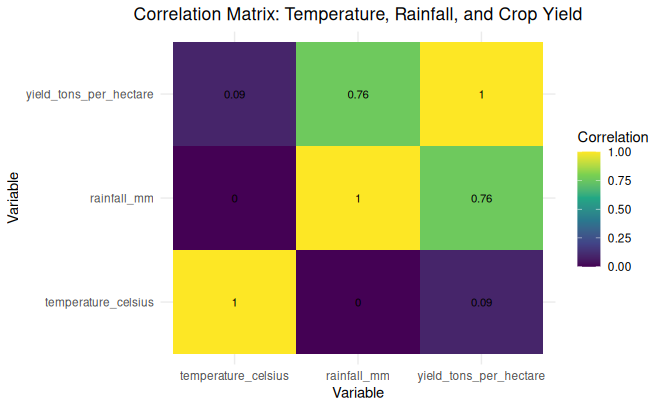

```r
# Convert the correlation matrix into a data frame for plotting
corr_data <- as.data.frame(as.table(corr_matrix))

# Round the correlation values to 2 decimal places
corr_data$Freq <- round(corr_data$Freq, 2)

# Create heatmap using plot
ggplot(corr_data, aes(Var1, Var2, fill = Freq)) +
  geom_tile() +
  geom_text(aes(label = Freq), colour = "black", size = 3) +  # to add text labels
  scale_fill_viridis_c() +  # Color scale for correlation values
  labs(title = "Correlation Matrix: Temperature, Rainfall, and Crop Yield",
       x = "Variable",
       y = "Variable",
       fill = "Correlation") +
  theme_minimal() +
  theme(plot.title = element_text(hjust = 0.5))
```

Temperature and Yield (0.09): The correlation between temperature and crop yield is weakly positive (0.09). This means that there is a very slight positive relationship between temperature and crop yield, although this correlation is not strong enough to draw definitive conclusions.

Rainfall and Yield (0.8): The correlation between rainfall and crop yield is strong (0.8), suggesting that rainfall has a significant positive effect on crop yield. As rainfall increases, crop yield tends to increase as well, which aligns with the general understanding that more water supports better crop growth.

**Are certain crops more successful in specific regions and if so, what factors (e.g., temperature, soil type) contribute to this?**

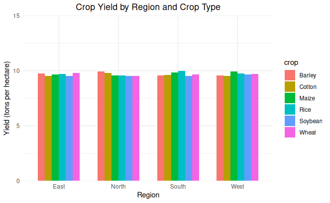

```r
data %>%
  ggplot(aes(x = region, y = yield_tons_per_hectare, fill = crop)) +
  geom_bar(stat = "identity", position = "dodge", width = 0.7) +
  scale_y_continuous(limits = c(0, 15), expand = c(0,0)) +
  labs(title = "Crop Yield by Region and Crop Type",
       x = "Region",
       y = "Yield (tons per hectare)") +
  theme_minimal() +
  theme(plot.title = element_text(hjust = 0.5))
```

```r
# Linear regression to assess the influence of temperature and soil type on yield
lm_model <- lm(yield_tons_per_hectare ~ temperature_celsius + soil_type + region, data = data)
summary(lm_model)
```

```
Call:
lm(formula = yield_tons_per_hectare ~ temperature_celsius + soil_type +
    region, data = data)

Residuals:
    Min      1Q  Median      3Q     Max
-4.8911 -1.2296  0.0004  1.2255  5.3668

Coefficients:
                      Estimate Std. Error t value Pr(>|t|)
(Intercept)          4.1000234  0.0081931 500.423   <2e-16 ***
temperature_celsius  0.0200059  0.0002339  85.515   <2e-16 ***
soil_typeClay       -0.0078558  0.0058534  -1.342   0.1796
soil_typeLoam       -0.0014890  0.0058495  -0.255   0.7991
soil_typePeaty      -0.0027320  0.0058539  -0.467   0.6407
soil_typeSandy      -0.0046746  0.0058467  -0.800   0.4240
soil_typeSilt       -0.0046243  0.0058506  -0.790   0.4293
regionNorth          0.0087244  0.0047784   1.826   0.0679 .
regionSouth          0.0031700  0.0047789   0.663   0.5071
regionWest           0.0034871  0.0047789   0.730   0.4656
---
Signif. codes:  0 ‘***’ 0.001 ‘**’ 0.01 ‘*’ 0.05 ‘.’ 0.1 ‘ ’ 1

Residual standard error: 1.689 on 999759 degrees of freedom
Multiple R-squared:  0.007267,  Adjusted R-squared:  0.007258
F-statistic: 813.2 on 9 and 999759 DF,  p-value: < 2.2e-16
```

### **Crop Yield by Region and Crop Type:**

The chart shows how different crop types perform in various regions:

- **Wheat:** Most successful in the **East region**, where the yield is higher compared to other regions.
- **Barley:** Performs best in the **North region**, with higher yields there.
- **Rice:** Shows a significant yield increase in the **South**, indicating it thrives in this region’s conditions.
- **Maize:** Exhibits the highest yields in the **West region**, suggesting it grows particularly well there.

### **Further Analysis of Temperature and Soil Type:**

Further analysis was conducted to assess the impact of **temperature** and **soil type** on crop yield, which might explain why certain crops perform better in specific regions.

The coefficients for soil types (e.g., **Clay, Loam, Peaty, Sandy, Silt**) are all not statistically significant, as their p-values are much greater than the typical threshold (0.05):

This suggests that soil type, in this model, does not have a significant impact on crop yield after accounting for temperature and region.

Insights:

- Temperature has a significant positive impact on crop yield, with higher temperatures associated with higher yields, albeit with a small effect size.
- **Soil Type:** Soil type did not show a significant effect on yield in this analysis. While soil characteristics often play an essential role in crop production, other factors (like irrigation, temperature and region) may have a more dominant effect on yield in this case.
- Region has a small effect, but only the North region shows a marginally significant positive effect on yield.

## A supervised regression tree model for yield prediction

```r
# predict crop yield
# target variable is yield_tons_per_hectare
data$yield_tons_per_hectare <- as.numeric(data$yield_tons_per_hectare)

# one hot encode categorical variables
# define a function to process one hot encoding and feature engineering

preprocess_data <- function(data) {
  data$region <- as.factor(data$region)
  data$soil_type <- as.factor(data$soil_type)
  data$crop <- as.factor(data$crop)
  data$rainfall_mm <- as.numeric(data$rainfall_mm)
  data$temperature_celsius <- as.numeric(data$temperature_celsius)
  data$fertilizer_used <- as.factor(data$fertilizer_used)
  data$irrigation_used <- as.factor(data$irrigation_used)
  data$weather_condition <- as.factor(data$weather_condition)
  data$days_to_harvest <- as.numeric(data$days_to_harvest)

  return(data)
}

process_data <- preprocess_data(data = data)
```

```r
process_data <- preprocess_data(data = data)
```

```r
# select features
features <- c('region', 'soil_type', 'crop', 'rainfall_mm', 'temperature_celsius', 'fertilizer_used', 'irrigation_used', 'weather_condition', 'days_to_harvest')

# split the data into training and testing
# set seed for reproducibility
# load libraries
set.seed(123)
library(rpart)
library(rpart.plot)
library(caret)
# prepare the data set
model_data <- process_data
model_data <- model_data %>% select(all_of(features), yield_tons_per_hectare)

train_index <- createDataPartition(model_data$yield_tons_per_hectare, p = 0.7, list = FALSE)
train_data <- model_data[train_index,]
test_data <- model_data[-train_index,]
```

```r
# train the decision model
tree_model <- rpart(yield_tons_per_hectare ~ .,
                    data = train_data,
                    method = "anova"
                    )

# print tree model
print(tree_model)
```

```
n= 699841

node), split, n, deviance, yval
      * denotes terminal node

 1) root 699841 2012150.00 4.650936
   2) rainfall_mm< 545.6997 346204  555349.90 3.515225
     4) fertilizer_used=False 173130  179457.10 2.765140
       8) irrigation_used=False 86775   58297.80 2.167795
        16) rainfall_mm< 317.6553 42388   15136.94 1.603671 *
        17) rainfall_mm>=317.6553 44387   16789.67 2.706512 *
       9) irrigation_used=True 86355   59082.24 3.365392
        18) rainfall_mm< 323.2004 43067   16054.59 2.805509 *
        19) rainfall_mm>=323.2004 43288   16096.28 3.922416 *
     5) fertilizer_used=True 173074  181046.00 4.265553
      10) irrigation_used=False 86265   58765.41 3.661096
        20) rainfall_mm< 325.4627 43980   16398.70 3.115212 *
        21) rainfall_mm>=325.4627 42285   15630.18 4.228863 *
      11) irrigation_used=True 86809   59441.28 4.866221
        22) rainfall_mm< 329.5572 44662   16923.11 4.324606 *
        23) rainfall_mm>=329.5572 42147   15533.49 5.440155 *
   3) rainfall_mm>=545.6997 353637  573090.90 5.762775
     6) fertilizer_used=False 176770  186834.20 5.013078
      12) irrigation_used=False 88546   62112.00 4.418727
        24) rainfall_mm< 776.26 44756   17198.51 3.857365 *
        25) rainfall_mm>=776.26 43790   16394.69 4.992473 *
      13) irrigation_used=True 88224   62049.66 5.609599
        26) rainfall_mm< 770.6541 43947   16840.53 5.041142 *
        27) rainfall_mm>=770.6541 44277   16912.63 6.173819 *
     7) fertilizer_used=True 176867  187605.60 6.512061
      14) irrigation_used=False 88589   62085.98 5.910126
        28) rainfall_mm< 777.3839 45445   17422.76 5.357556 *
        29) rainfall_mm>=777.3839 43144   16171.41 6.492167 *
      15) irrigation_used=True 88278   61210.49 7.116116
        30) rainfall_mm< 775.3017 44592   16846.16 6.557907 *
        31) rainfall_mm>=775.3017 43686   16286.66 7.685902 *
```

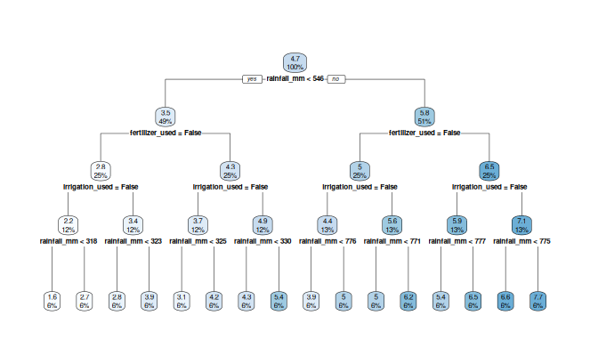

```r
# Visualize the tree model
rpart.plot(tree_model)
```

**Model Performance**

```r
# prediction
prediction <- predict(tree_model, test_data, type = "vector")
```

```r
# Actual values from the test data
actual_values <- test_data$yield_tons_per_hectare
```

**R-Squared (R²)**

```r
# Calculate R-squared (R²)
ss_total <- sum((actual_values - mean(actual_values))^2)
ss_residual <- sum((actual_values - prediction)^2)
r_squared <- 1 - (ss_residual / ss_total)

print(paste("R-squared:", r_squared))
```

```
[1] "R-squared: 0.868926523988275"
```

### Interpretation of R-squared:

**Root Mean Squared Error**

```r
# Calculate RMSE (Root Mean Squared Error)
rmse <- sqrt(mean((prediction - actual_values)^2))
print(paste("RMSE:", rmse))
```

```
[1] "RMSE: 0.613328515079322"
```

- **RMSE (Root Mean Squared Error)** measures the average magnitude of the errors in the predictions. It gives an idea of how far off the predictions are from the actual values.
- A **RMSE of 0.613** means that, on average, the predicted crop yield is off by about **0.613 tons per hectare** from the actual crop yield.
- **Lower RMSE values** indicate that the model is making more accurate predictions.
- An RMSE of **0.613** could be considered quite good, depending on the range of crop yield in your dataset. If the crop yield varies greatly (e.g., ranging from 0 to 10 tons per hectare), then an RMSE of 0.613 might be a reasonable error.

**Conclusion:**

The analysis of crop yield data across different regions and crop types reveals some valuable insights:

**Regional Crop Preferences:**

- Wheat performs best in the East, where regional conditions likely favor its growth.
- Barley yields the highest in the North, indicating it thrives in the conditions there.
- Rice shows the most significant yield increase in the South, suggesting this region provides optimal conditions for its growth.
- Maize achieves the highest yield in the West, highlighting regional differences in crop success.

**Temperature’s Influence on Crop Yield:**

- Temperature plays a significant role in increasing crop yield. Higher temperatures generally lead to higher yields, which might explain the regional differences in crop success. For instance, wheat’s success in the East region could be due to more favourable temperature conditions.

**Soil Type’s Impact:**

- Soil type did not have a statistically significant effect on crop yield in this analysis. This suggests that while soil type is important, other factors such as temperature and regional conditions (like rainfall and irrigation) may have a stronger impact on crop yield.

**Irrigation’s Impact:**

- The use of irrigation shows a significant positive effect on crop yield, with yields noticeably higher.

**Fertilizer’s Impact:**

- The application of fertilizer (True) is associated with a noticeable increase in crop yield.

**Rainfall’s impact:**

- As rainfall increases, crop yield tends to increase as well, which aligns with the general understanding that more water supports better crop growth.

**Deployment**

Shiny App (Interactive Web App)

```r
# Save model
saveRDS(tree_model, "./05_model/tree_model.rds")

# The app.R is located in the main directory
```

**Deliverables:**

Insights and visualizations were shared via:

- **GitHub Repository: Includes documentation, R script and data files.**